# data_visualization_graph

becker

2018-07-22

## Data Visualization | Springboard - Capstone Project

### Identifying paying subscribers

##### Paying Subscribers

###### Here, we are segmenting only the paying customers at Wishpond. It is useful to understand what are the factors that generate most of Wishpond revenue.

```r
wp_data_subscribed <- wp_data %>% filter(Unsubscribed == "FALSE", plan_name != "Unknown",plan_name != "Starter")
```

##### All Subscribed customers | Starters - Free plan | Basic - cheapest plan | Pro - Intermediate | Growth Plan - Most Expensive Plan

###### The graph below show us what the most popular plans at Wishpond are. The interesting thing here is that most of the customers are on the Starter plan, which means that they have not paid Wishpond yet. Although, starter plan does not contain much data, it shows a great opportunity for Wishpond to grow. If we understand what it takes customers to use Wishpond, we might be able to get people from the Starter plan to sign-up with Wishpond.

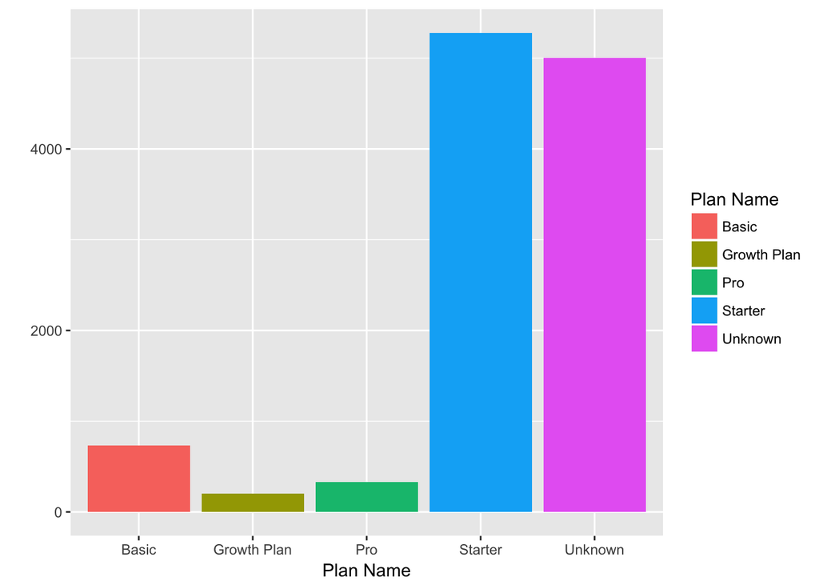

```r
wp_data_subscribed_all <- wp_data %>%  filter(Unsubscribed == "FALSE")
ggplot(wp_data_subscribed_all, aes(plan_name)) +
  geom_bar(stat = "count", aes(fill = plan_name)) +
  xlab("Plan Name") +
  ylab("") +
  scale_fill_discrete(name = "Plan Name")
```

### Paying subscribers and how they are using the platform

##### Total amount of leads and their plan

###### By looking at the graph we can understand how customers are using Wishpond to generate leads. While Wishpond has many different tools with different purposes, most of its tools are aimed to generate leads. If customers have no or almost no lead, it can be a high indicative that they might be close to cancel their subscription.

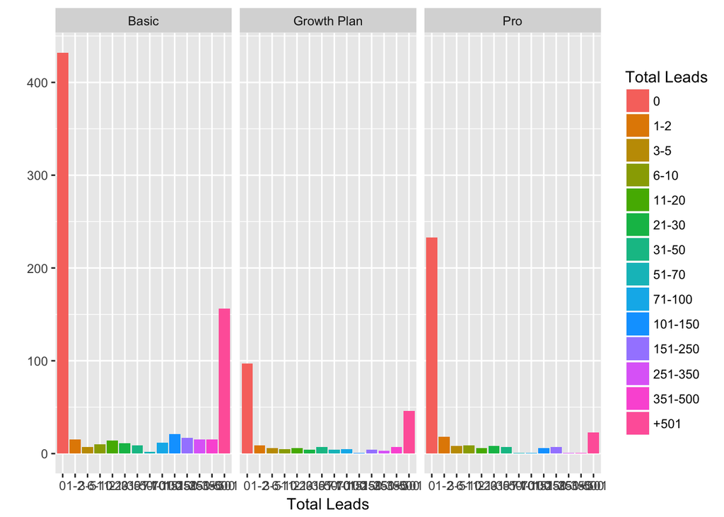

```r
ggplot(wp_data_subscribed, aes(factor(wp_data_subscribed$total_leads))) +
  geom_bar(stat = "count", aes(fill = factor(wp_data_subscribed$total_leads))) +
  facet_grid(. ~ factor(wp_data_subscribed$plan_name)) +
  xlab("Total Leads") +
  ylab("") +
  scale_fill_discrete(name = "Total Leads")
```

##### Total amount of tools and their plan

###### Some of the important features at Wishpond are marketing automation, pop-ups and forms, if clients are not using these extra tools, they are not exploring the platform and not integrating their business even further with Wishpond. The main goal is to get customers entire marketing cycle to Wishpond. By looking at the graph, we see that there are a lot of customers that havent used or have barely used Wishpond tools. Thus, showing an opportunity for growth. if we can inform customers better on how these tools function.

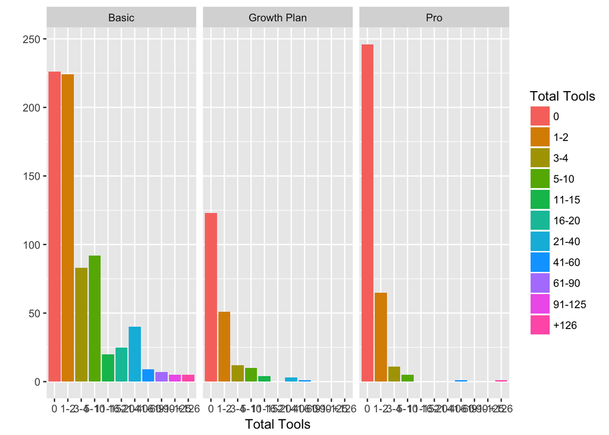

```r
ggplot(wp_data_subscribed, aes(factor(wp_data_subscribed$total_live_tools))) +
  geom_bar(stat = "count", aes(fill = factor(wp_data_subscribed$total_live_tools))) +
  facet_grid(. ~ factor(wp_data_subscribed$plan_name)) +
  xlab("Total Tools") +
  ylab("") +
  scale_fill_discrete(name = "Total Tools")
```

##### Customers that havent acquired any leads nor created any tools

###### If customers are not generating leads and not using any of the tools, there will be no purpose for them to stay subscribed at Wishpond. The graph below shows a scary amount of customers that havent done either. What is more striking is the number of growth plan users that havent acquired any leads nor used any tools, as it is the most expensive plan.

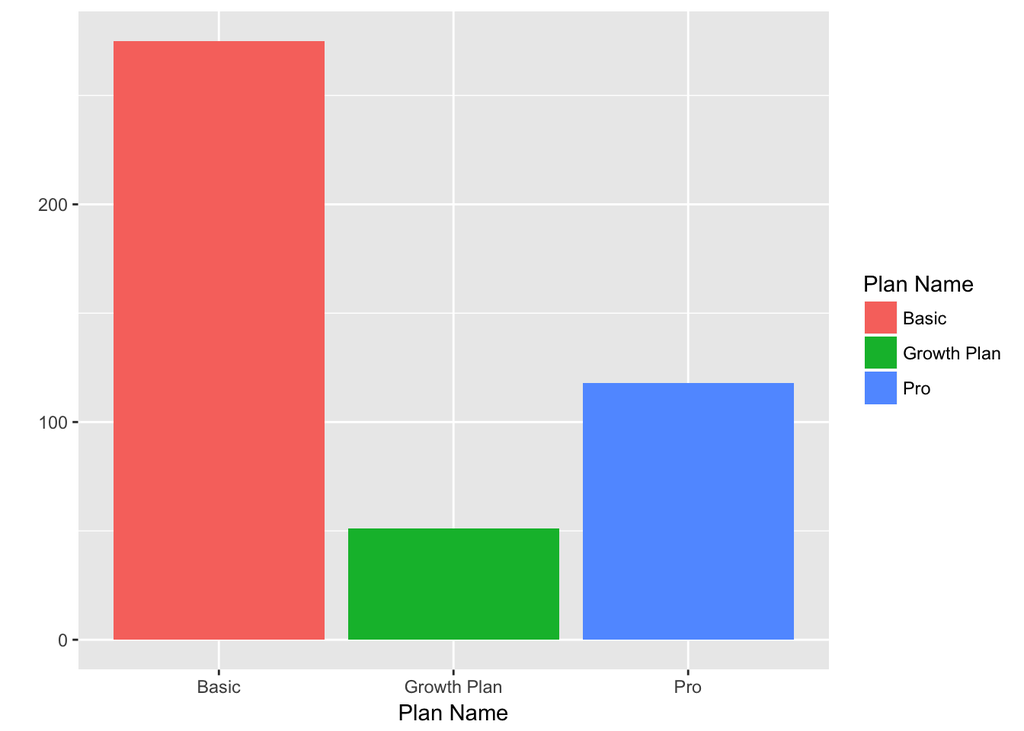

```r
wp_data_subscribed_nothing <- wp_data %>% filter(Unsubscribed == "FALSE", plan_name != "Unknown", plan_name != "Starter", total_live_tools == 0, total_leads ==0)
ggplot(wp_data_subscribed_nothing, aes(plan_name)) +
  geom_bar(stat = "count", aes(fill = plan_name)) +
  xlab("Plan Name") +
  ylab("") +
  scale_fill_discrete(name = "Plan Name")
```

##### Live Landings Pages & Live Workflows

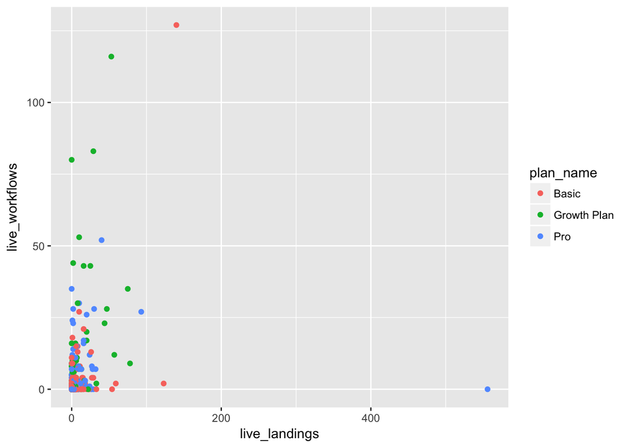

```r
ggplot(wp_data_subscribed, aes(live_landings, live_workflows, color= plan_name)) +
  geom_point()
```

### Sales Agents Or Affiliated - Who are the ones generating most sales/customers?

##### Sales Agents - Customers’ plan & if they came through a demo with a sales agent

###### The graoh shows that most of the subscriptions are not coming through sales agents, but through other means. The sales team is fairly expensive with a lot of personnel. Thus, Wishpond could reduce expenses by decreasing the sales team abd increase revenue by focusing on the different avenues that are bringing more customers.

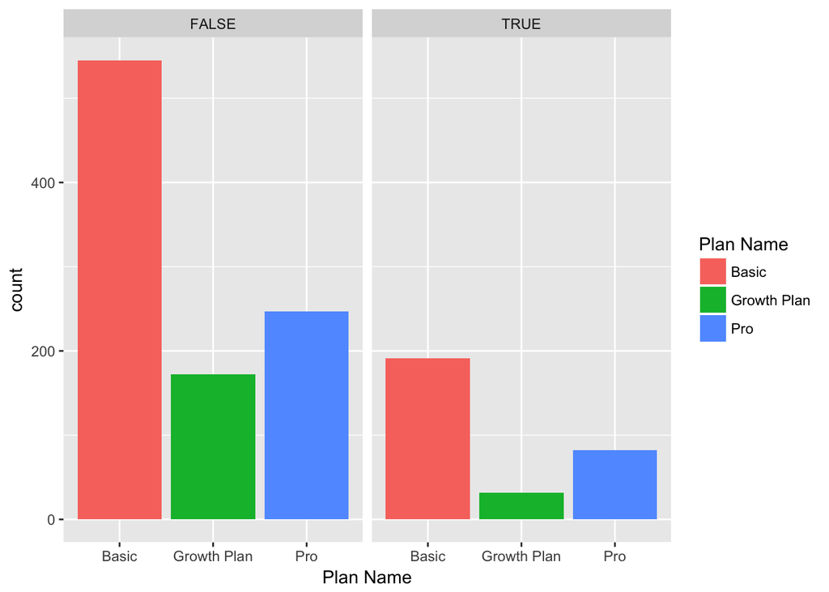

```r
ggplot(wp_data_subscribed, aes(factor(wp_data_subscribed$plan_name))) +
  geom_bar(stat = "count", aes(fill = factor(wp_data_subscribed$plan_name))) +
  facet_grid(. ~ factor(wp_data_subscribed$sales)) +
  xlab("Plan Name") +
  scale_fill_discrete(name = "Plan Name")
```

##### Affiliated - Customers’ plan & if they came through an affiliated link

###### While affiliated links have not generated as many sales as sales agents, the number are not too far off. Also, the amount of money spent on an affiliated link is much less than a sales agent salary. Pushing the affiliated program could be a good alternative to bring more customers to Wishpond at a lower cost.

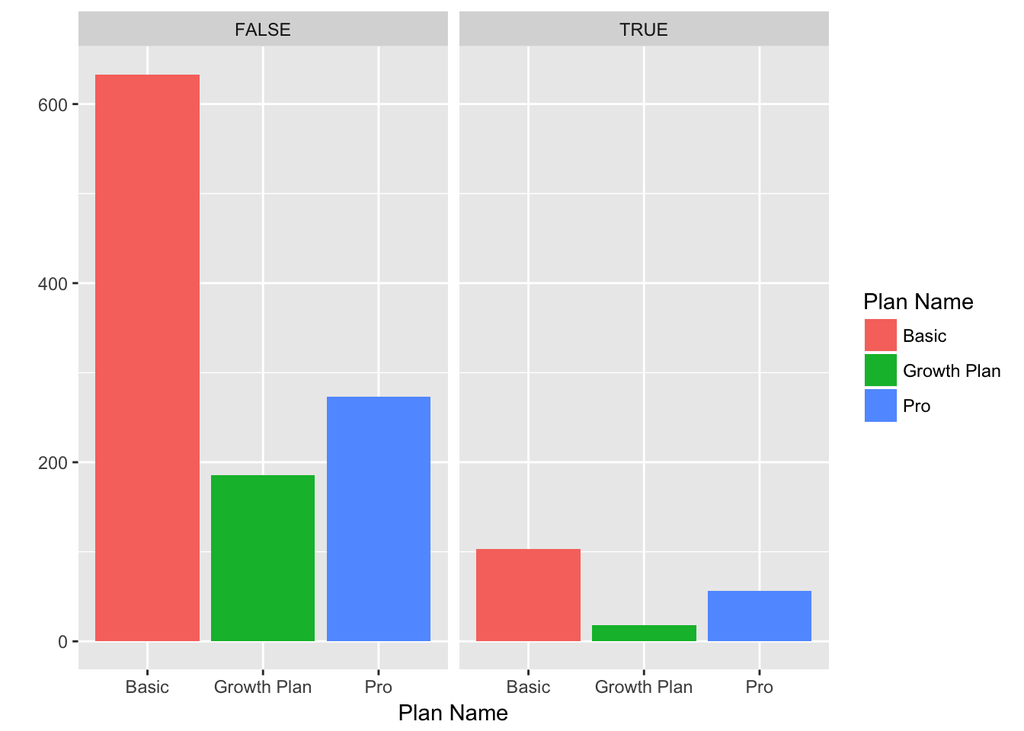

```r
ggplot(wp_data_subscribed, aes(factor(wp_data_subscribed$plan_name))) +
  geom_bar(stat = "count", aes(fill = factor(wp_data_subscribed$plan_name))) +
  facet_grid(. ~ factor(wp_data_subscribed$affiliated)) +
  xlab("Plan Name") +
  ylab("") +
  scale_fill_discrete(name = "Plan Name")
```

### Blog - Current subscribed customers engaging with the Wishpond Blog (Trying to learn new ways to generate more leads)?

##### Customers plan & if they have read the blog

###### Interesting to see if there is a possibility of influence from the blog in bringing customers to Wishpond or influencing them to select a specific plan. The graph below shows us that the majority of customers at the Basic plan have read the blog but at the Growth plan less than half have read the blog. Probably because a lot of customers at the basic are trying to understand new ways to generate leads, while growth are at a more advanced understanding on how marketing works.

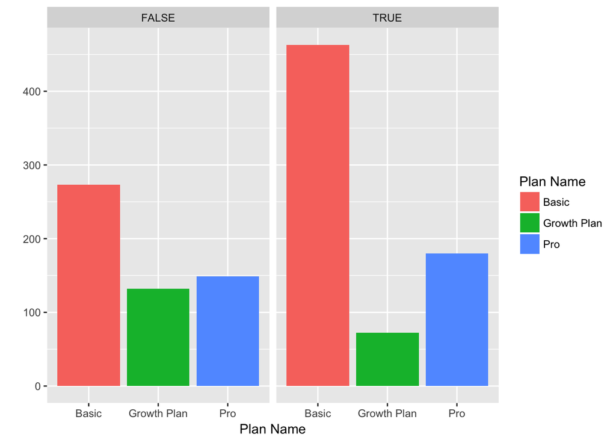

```r
ggplot(wp_data_subscribed, aes(factor(wp_data_subscribed$plan_name))) +
  geom_bar(stat = "count", aes(fill = factor(wp_data_subscribed$plan_name))) +
  facet_grid(. ~ factor(wp_data_subscribed$read_blog)) +
  xlab("Plan Name") +
  ylab("") +
  scale_fill_discrete(name = "Plan Name")
```

##### Blog impact in lead generation

###### While there is a large number of people that have read the blog and have not generated any lead, the graph shows that those who have read the blog have a generated more leads. Therefore, if there is a marketing strategy in place to push blog to current customers, the amount of leads of each customers could increase and turn them into a more loyal customer.

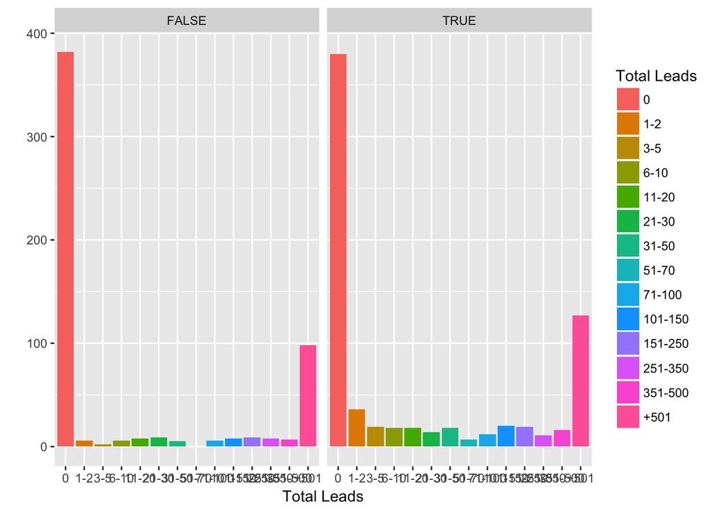

```r
ggplot(wp_data_subscribed, aes(factor(wp_data_subscribed$total_leads))) +
  geom_bar(stat = "count", aes(fill = factor(wp_data_subscribed$total_leads))) +
  facet_grid(. ~ factor(wp_data_subscribed$read_blog)) +
  xlab("Total Leads") +
  ylab("") +
  scale_fill_discrete(name = "Total Leads")
```

##### Blog impact in tools creation

###### Similar to the amount of leads, we want to see how the blog is influencing customers on creating different tools at Wishpond. The interesting factor on this graph is that most of the customers that have read the blog are not using Wishpond tools as much as those who have not read it. Therefore, Wishpond should allocate some space to talk about the importance of using workflows, pop-up and other tools, in order to get customers to use more of Wishpond tools.

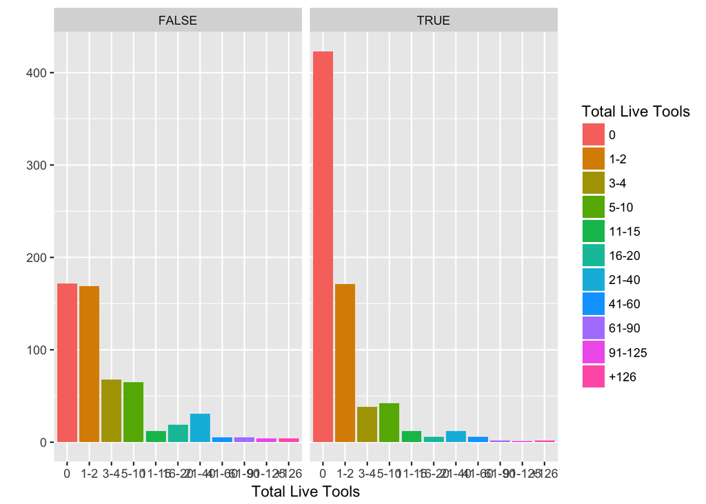

```r
ggplot(wp_data_subscribed, aes(factor(wp_data_subscribed$total_live_tools))) +
  geom_bar(stat = "count", aes(fill = factor(wp_data_subscribed$total_live_tools))) +
  facet_grid(. ~ factor(wp_data_subscribed$read_blog)) +
  xlab("Total Live Tools") +
  ylab("") +
  scale_fill_discrete(name = "Total Live Tools")
```

### What are the business industries bringing the most revenue to Wishpond?

###### From the graph below we can see that e-commerce is the leading business industry on Wishpond, while agency get a good share of customers. By analysing the graph for the starter plan, we can understand where most of the opportunity to turn customers to paid customers are, e-commerce and agency. At the Growth plan, the most expensive plan, e-commerce is by far the most predominant business industry. It shows us where Wishpond should start focusing on in order to bring more customers.

##### Starter Plan & Business Industry

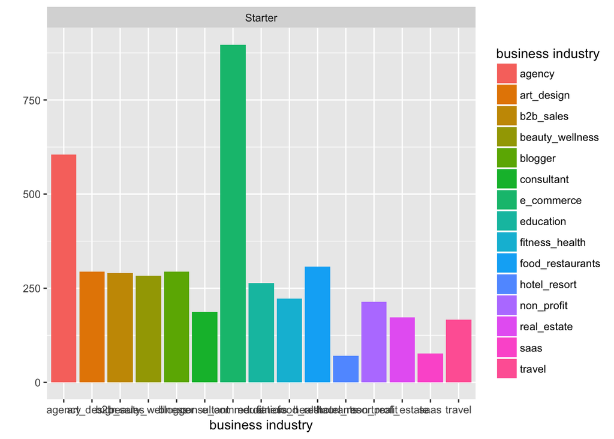

```r
wp_data_starter <- wp_data %>% filter(plan_name == "Starter", Unsubscribed == "FALSE", business_industry != "Other")
ggplot(wp_data_starter, aes(factor(wp_data_starter$business_industry))) +
  geom_bar(stat = "count", aes(fill = factor(wp_data_starter$business_industry))) +
  facet_grid(. ~ factor(wp_data_starter$plan_name)) +
  xlab("business industry") +
  ylab("") +
  scale_fill_discrete(name = "business industry")
```

##### Basic Plan & Business Industry

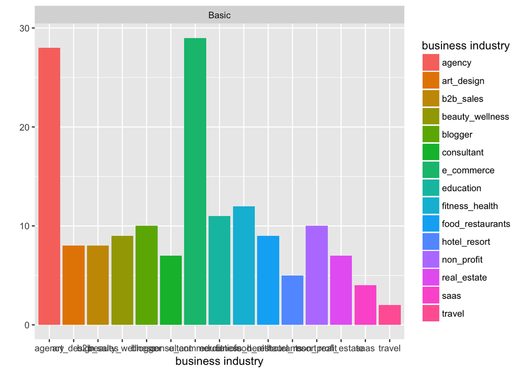

```r
wp_data_basic <- wp_data %>% filter(plan_name == "Basic", Unsubscribed == "FALSE", business_industry != "Other")
ggplot(wp_data_basic, aes(factor(wp_data_basic$business_industry))) +
  geom_bar(stat = "count", aes(fill = factor(wp_data_basic$business_industry))) +
  facet_grid(. ~ factor(wp_data_basic$plan_name)) +
  xlab("business industry") +
  ylab("") +
  scale_fill_discrete(name = "business industry")
```

##### Pro Plan & Business Industry | Second Most Expensive Plan | E-Commerce by far the most relevant one. Art-design and fitness health industry coming in second

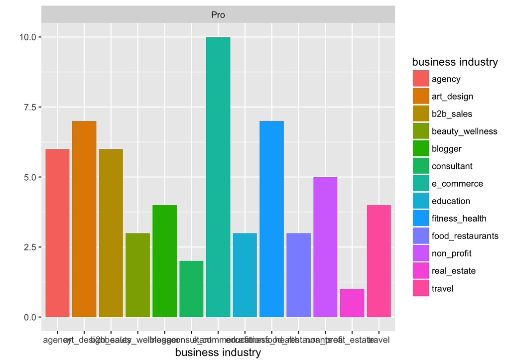

```r
wp_data_pro <- wp_data %>% filter(plan_name == "Pro", Unsubscribed == "FALSE", business_industry != "Other")
ggplot(wp_data_pro, aes(factor(wp_data_pro$business_industry))) +
  geom_bar(stat = "count", aes(fill = factor(wp_data_pro$business_industry))) +
  facet_grid(. ~ factor(wp_data_pro$plan_name)) +
  xlab("business industry") +
  ylab("") +
  scale_fill_discrete(name = "business industry")
```

##### Growth Plan & Business | Most Expensive Plan | E-Commerce by far again bringing the most customers to Growth plan.

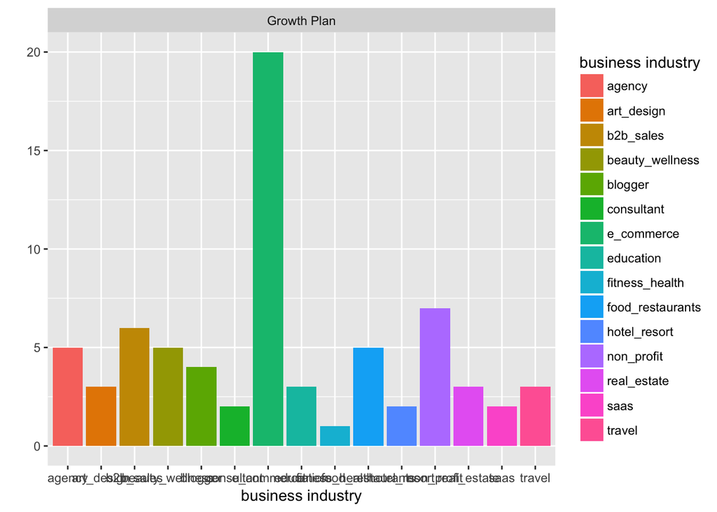

```r
wp_data_growth <- wp_data %>% filter(plan_name == "Growth Plan", Unsubscribed == "FALSE", business_industry != "Other")
ggplot(wp_data_growth, aes(factor(wp_data_growth$business_industry))) +
  geom_bar(stat = "count", aes(fill = factor(wp_data_growth$business_industry))) +
  facet_grid(. ~ factor(wp_data_growth$plan_name)) +
  xlab("business industry") +
  ylab("") +
  scale_fill_discrete(name = "business industry")
```

### What business industries unsubscribed customers belong to?

##### Unsubscribed Customers & their business industry

###### The graph below shows us that e-commerce and agency are the business industries with the most cancels, similar to the highest amount of customers. However, by knowing that these are the greatest numbers of cancel, we can learn what keep customers from these business industries subscribeed at Wishpond and eventually decrease the number of cancels.

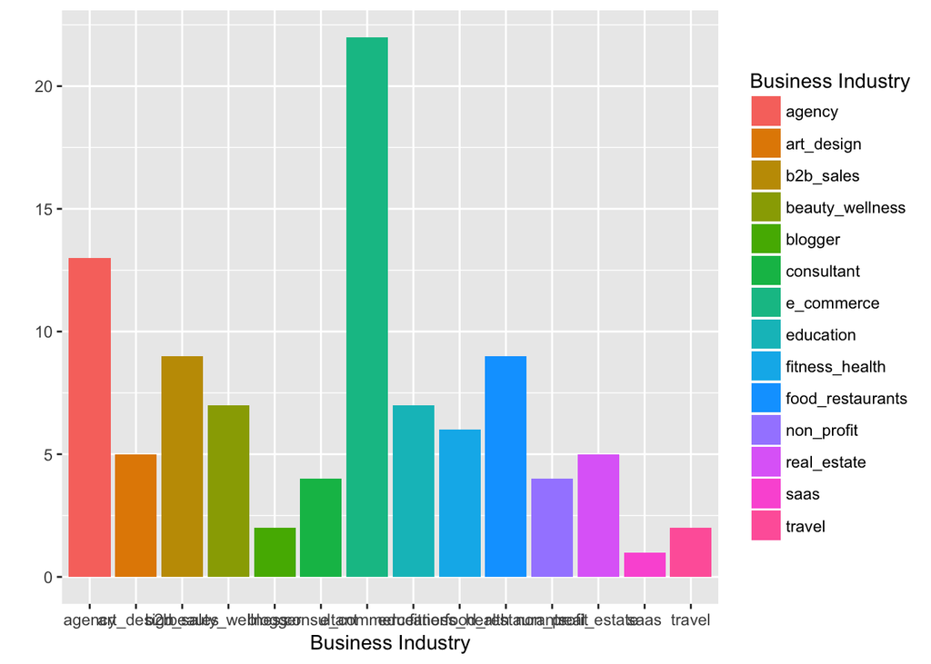

```r
wp_data_unsubscribed <- wp_data %>% filter(Unsubscribed == "TRUE", business_industry != "Other")
ggplot(wp_data_unsubscribed, aes(factor(wp_data_unsubscribed$business_industry))) +
  geom_bar(stat = "count", aes(fill = factor(wp_data_unsubscribed$business_industry))) +
  xlab("Business Industry") +
  ylab("") +
  scale_fill_discrete(name = "Business Industry")
```